# Final Project on stat331 offerd by Stanford University taught by Professor Lu Tian

# Reference:

Confidence Bands for Survival Curves Under the Proportional Hazards Model Author(s): D. Y. Lin, T. R. Fleming and L. J. Wei Source: Biometrika, Vol. 81, No. 1 (Mar., 1994), pp. 73-81 Published by: Biometrika Trust Stable URL: http://www.jstor.org/stable/2337051

Please read the guideline to the project: “project.pdf”

# load the library

```r
library(survival)
library(survminer)
```

# Load the data

```r
data=read.table("peacedata.csv", head=T, sep=",")
attach(data)
```

# Check the data

```r
summary(data)
```

```
    t2death          death               tx              age
 Min.   : 0.00   Min.   :0.00000   Min.   :0.0000   Min.   :50.00
 1st Qu.:47.87   1st Qu.:0.00000   1st Qu.:0.0000   1st Qu.:58.00
 Median :57.53   Median :0.00000   Median :1.0000   Median :64.00
 Mean   :56.98   Mean   :0.07642   Mean   :0.5014   Mean   :64.33
 3rd Qu.:67.84   3rd Qu.:0.00000   3rd Qu.:1.0000   3rd Qu.:70.00
 Max.   :88.97   Max.   :1.00000   Max.   :1.0000   Max.   :83.00
     sysbp           gender        hidiabet         hihypert
 Min.   : 98.0   Min.   :0.00   Min.   :0.0000   Min.   :0.0000
 1st Qu.:120.0   1st Qu.:0.00   1st Qu.:0.0000   1st Qu.:0.0000
 Median :132.0   Median :0.00   Median :0.0000   Median :0.0000
 Mean   :133.4   Mean   :0.18   Mean   :0.1666   Mean   :0.4544
 3rd Qu.:144.0   3rd Qu.:0.00   3rd Qu.:0.0000   3rd Qu.:1.0000
 Max.   :184.0   Max.   :1.00   Max.   :1.0000   Max.   :1.0000
```

```r
# No missing values, but still needs to factorize variables
head(data)
```

|  | t2death | death | tx | age | sysbp | gender | hidiabet | hihypert |
| --- | --- | --- | --- | --- | --- | --- | --- | --- |
| 1 | 53.91376 | 0 | 1 | 58 | 150 | 0 | 1 | 1 |
| 2 | 31.50719 | 1 | 0 | 68 | 144 | 0 | 0 | 1 |
| 3 | 53.58522 | 0 | 0 | 65 | 140 | 0 | 0 | 0 |
| 4 | 82.36550 | 0 | 0 | 64 | 184 | 0 | 0 | 1 |
| 5 | 42.15195 | 0 | 1 | 61 | 110 | 0 | 0 | 0 |
| 6 | 65.41273 | 0 | 0 | 57 | 132 | 0 | 0 | 1 |

```r
names(data)
```

```
[1] "t2death"  "death"    "tx"       "age"      "sysbp"    "gender"
[7] "hidiabet" "hihypert"
```

```r
dim(data)
```

```
[1] 8283    8
```

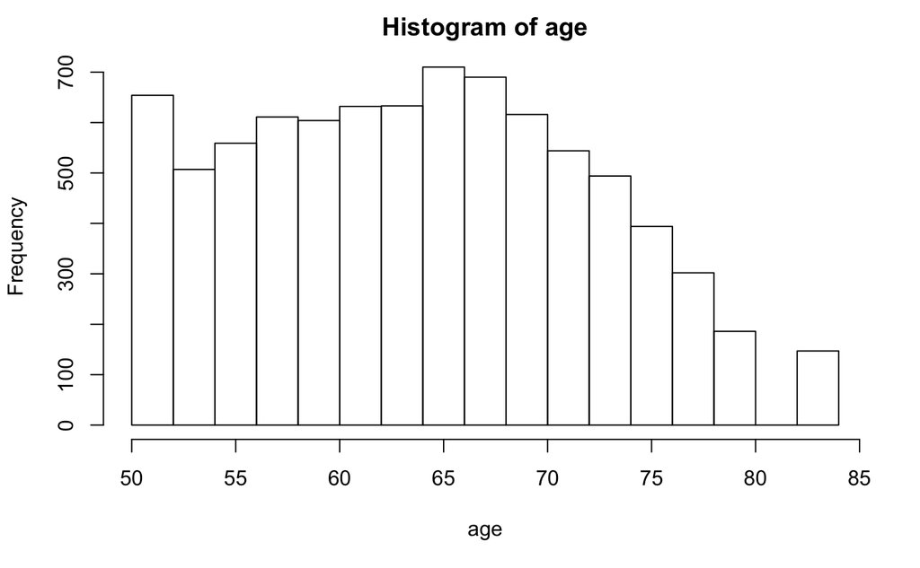

```r
hist(age)
```

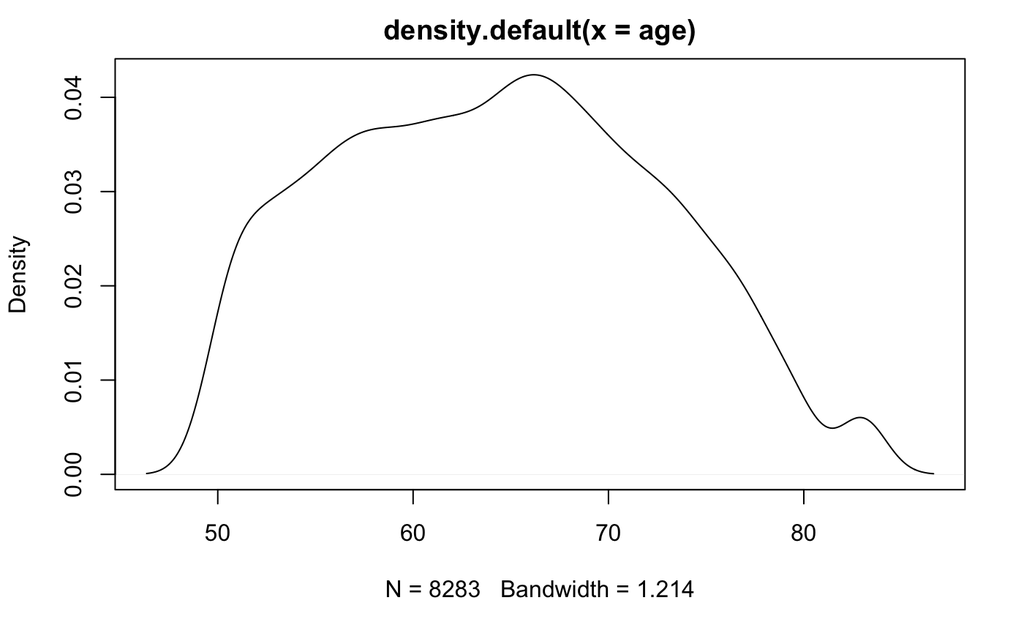

```r
plot(density(age))
```

```r
table(hidiabet)
```

```
hidiabet
   0    1
6903 1380
```

```r
table(hihypert)
```

```
hihypert
   0    1
4519 3764
```

```r
table(tx)
```

```
tx
   0    1
4130 4153
```

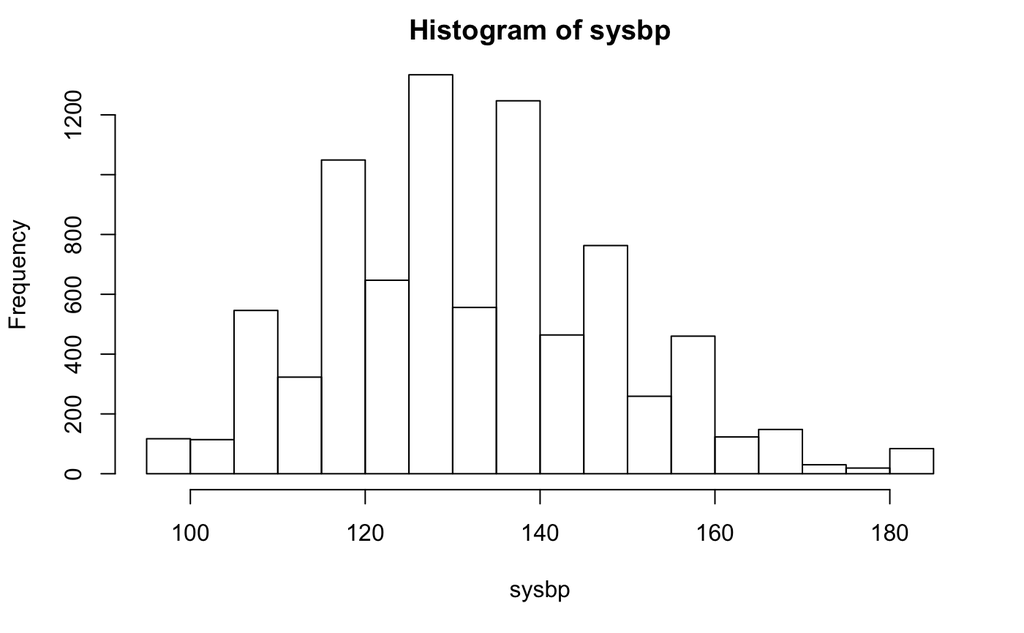

```r
hist(sysbp)
```

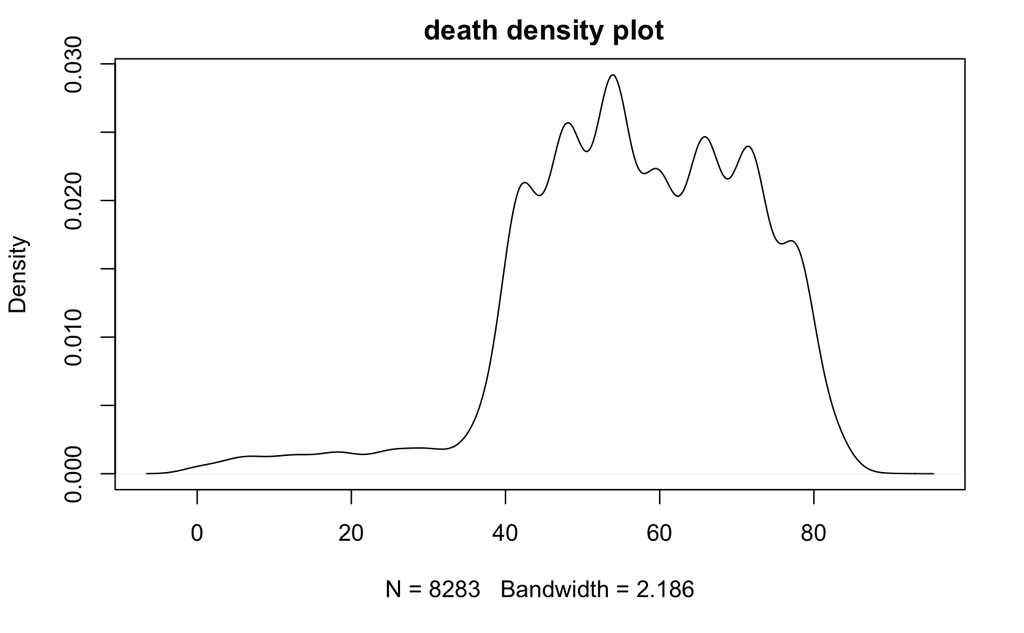

```r
plot(density(t2death), main=" death density plot")
```

# Data preprocessing

```r
data$tx <- as.factor(data$tx)
data$gender<- as.factor(data$gender)
data$hidiabet<- as.factor(data$hidiabet)
data$hihypert<- as.factor(data$hihypert)
```

# Surivival curve

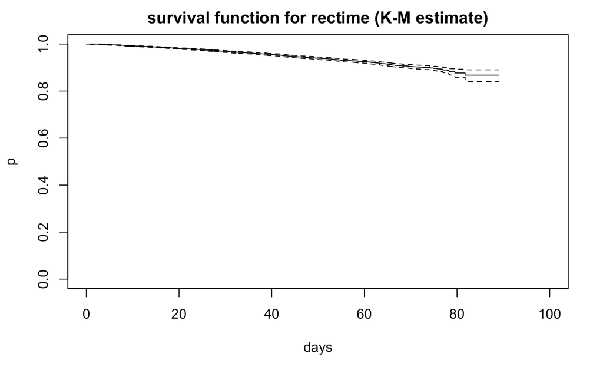

```r
KM <- survfit(Surv(t2death,death)~1,type="kaplan-meier", conf.type="log-log")
plot(KM, main="survival function for rectime (K-M estimate)", xlab="days", ylab="p",xlim = c(0,100))
```

# Task 1:

Conduct the logrank test to test the treatment effect of ACE-inhibitor therapy in reducing mortality

```r
survdiff(Surv(t2death,death)~tx,data = data)
```

```
Call:
survdiff(formula = Surv(t2death, death) ~ tx, data = data)

        N Observed Expected (O-E)^2/E (O-E)^2/V
tx=0 4130      334      315      1.13      2.26
tx=1 4153      299      318      1.12      2.26

 Chisq= 2.3  on 1 degrees of freedom, p= 0.1
```

Fail to reject H0 that treatment efect of ACE-inhibitor therapy does not work in reducing mortality

# Task 2:

Estimate the hazard ratio of the ACE-inhibitor versus the standard care only and construct the associated confidence interval based on the Cox regression model. Report your findings. Compare the p-value of the treatment effect with that from the logrank test. Why are they almost identical?

```r
cox<- coxph(Surv(t2death,death)~tx,data = data)
summary(cox)
```

```
Call:
coxph(formula = Surv(t2death, death) ~ tx, data = data)

  n= 8283, number of events= 633

        coef exp(coef) se(coef)      z Pr(>|z|)
tx1 -0.11955   0.88732  0.07962 -1.502    0.133

    exp(coef) exp(-coef) lower .95 upper .95
tx1    0.8873      1.127    0.7591     1.037

Concordance= 0.512  (se = 0.01 )
Likelihood ratio test= 2.26  on 1 df,   p=0.1
Wald test            = 2.25  on 1 df,   p=0.1
Score (logrank) test = 2.26  on 1 df,   p=0.1
```

Interpretation:

- At a given instant in time, someone who is having the treatment is 0.8873 times as likely to die as someone who is not having the treatment.
- We are 95% confident that the true HR is between 0.7591 and 1.037

*These are all tests for the null hypothesis: b1=0 v.s b1!=0*

# Task3

It is known that age, systolic blood pressure, gender, history of diabetes and history of hypertension are associated with the survival time. Estimate the hazard ratio of the the ACE-inhibitor versus the standard care only but adjusting for the aforementioned factors, using the multivariate Cox regression model. Report your fundings.

```r
coxm<- coxph(Surv(t2death,death)~.,data = data)
summary(coxm)
```

```
Call:
coxph(formula = Surv(t2death, death) ~ ., data = data)

  n= 8283, number of events= 633

               coef exp(coef)  se(coef)      z Pr(>|z|)
tx1       -0.134340  0.874293  0.079653 -1.687  0.09169 .
age        0.070440  1.072980  0.005126 13.742  < 2e-16 ***
sysbp      0.001197  1.001198  0.002443  0.490  0.62420
gender1   -0.348111  0.706020  0.109784 -3.171  0.00152 **
hidiabet1  0.565512  1.760348  0.091506  6.180 6.41e-10 ***
hihypert1  0.221465  1.247903  0.082814  2.674  0.00749 **
---
Signif. codes:  0 ‘***’ 0.001 ‘**’ 0.01 ‘*’ 0.05 ‘.’ 0.1 ‘ ’ 1

          exp(coef) exp(-coef) lower .95 upper .95
tx1          0.8743     1.1438    0.7479    1.0220
age          1.0730     0.9320    1.0623    1.0838
sysbp        1.0012     0.9988    0.9964    1.0060
gender1      0.7060     1.4164    0.5693    0.8755
hidiabet1    1.7603     0.5681    1.4713    2.1061
hihypert1    1.2479     0.8013    1.0609    1.4678

Concordance= 0.678  (se = 0.011 )
Likelihood ratio test= 256.5  on 6 df,   p=<2e-16
Wald test            = 250.7  on 6 df,   p=<2e-16
Score (logrank) test = 260.2  on 6 df,   p=<2e-16
```

# Task4

```r
male <- subset(data,data$gender==0)
female <- subset(data,data$gender==1)
summary(female)
```

```
    t2death          death         tx           age
 Min.   : 0.00   Min.   :0.00000   0:703   Min.   :50.00
 1st Qu.:48.10   1st Qu.:0.00000   1:788   1st Qu.:59.00
 Median :58.48   Median :0.00000           Median :66.00
 Mean   :57.56   Mean   :0.06707           Mean   :65.82
 3rd Qu.:68.53   3rd Qu.:0.00000           3rd Qu.:72.00
 Max.   :84.17   Max.   :1.00000           Max.   :83.00
     sysbp       gender   hidiabet hihypert
 Min.   : 98.0   0:   0   0:1176   0:668
 1st Qu.:124.0   1:1491   1: 315   1:823
 Median :134.0
 Mean   :135.6
 3rd Qu.:148.0
 Max.   :184.0
```

```r
summary(male)
```

```
    t2death          death         tx            age
 Min.   : 0.00   Min.   :0.00000   0:3427   Min.   :50.00
 1st Qu.:47.79   1st Qu.:0.00000   1:3365   1st Qu.:57.00
 Median :57.30   Median :0.00000            Median :64.00
 Mean   :56.85   Mean   :0.07847            Mean   :64.01
 3rd Qu.:67.72   3rd Qu.:0.00000            3rd Qu.:70.00
 Max.   :88.97   Max.   :1.00000            Max.   :83.00
     sysbp       gender   hidiabet hihypert
 Min.   : 98.0   0:6792   0:5727   0:3851
 1st Qu.:120.0   1:   0   1:1065   1:2941
 Median :130.0
 Mean   :132.9
 3rd Qu.:142.0
 Max.   :184.0
```

```r
coxmale<- coxph(Surv(t2death,death)~tx,data = male)
summary(coxmale)
```

```
Call:
coxph(formula = Surv(t2death, death) ~ tx, data = male)

  n= 6792, number of events= 533

        coef exp(coef) se(coef)      z Pr(>|z|)
tx1 -0.04218   0.95870  0.08668 -0.487    0.627

    exp(coef) exp(-coef) lower .95 upper .95
tx1    0.9587      1.043    0.8089     1.136

Concordance= 0.5  (se = 0.011 )
Likelihood ratio test= 0.24  on 1 df,   p=0.6
Wald test            = 0.24  on 1 df,   p=0.6
Score (logrank) test = 0.24  on 1 df,   p=0.6
```

```r
coxfe<- coxph(Surv(t2death,death)~tx,data = male)
summary(coxfe)
```

```
Call:
coxph(formula = Surv(t2death, death) ~ tx, data = male)

  n= 6792, number of events= 533

        coef exp(coef) se(coef)      z Pr(>|z|)
tx1 -0.04218   0.95870  0.08668 -0.487    0.627

    exp(coef) exp(-coef) lower .95 upper .95
tx1    0.9587      1.043    0.8089     1.136

Concordance= 0.5  (se = 0.011 )
Likelihood ratio test= 0.24  on 1 df,   p=0.6
Wald test            = 0.24  on 1 df,   p=0.6
Score (logrank) test = 0.24  on 1 df,   p=0.6
```

# Task5

The clinical investigator decides to develop prognostic regression models using the baseline age, systolic blood pressure, gender, history of diabetes and history of hypertension to predict the survival time for patients receiving the conventional therapy only and for patients receiving the ACE-inhibitor plus the conventional therapy.

To this end, one may build two separate Cox regression models in patient receiving the conventional therapy only (tx=0) and in patient receiving the ACE-inhibitor plus the conventional therapy (tx=1).

```r
data0 = subset(data,data$tx==0)
data0 <- subset(data0,select = -c(tx))

data1 = subset(data,data$tx==1)
data1 <- subset(data1,select = -c(tx))

model0 <- coxph(Surv(t2death,death)~.,data = data0)
model1 <- coxph(Surv(t2death,death)~.,data = data1)

cox.zph(model0)
```

```
          chisq df     p
age      0.6202  1 0.431
sysbp    4.4206  1 0.036
gender   0.1198  1 0.729
hidiabet 0.0119  1 0.913
hihypert 1.7139  1 0.190
GLOBAL   5.2452  5 0.387
```

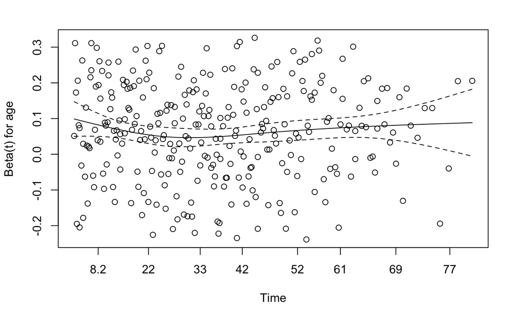

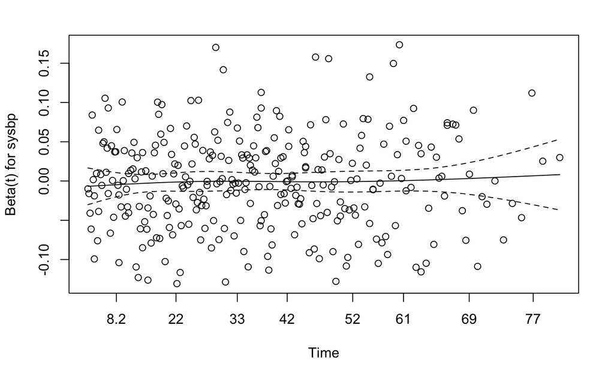

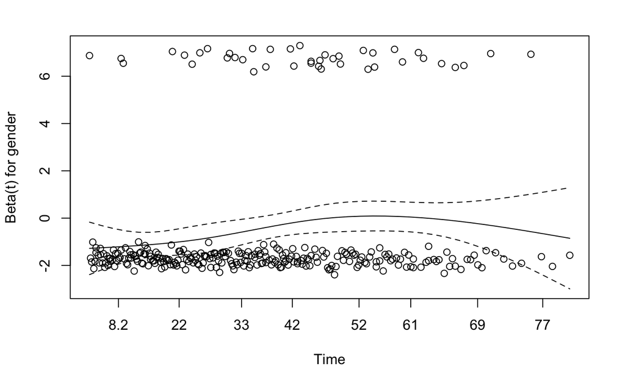

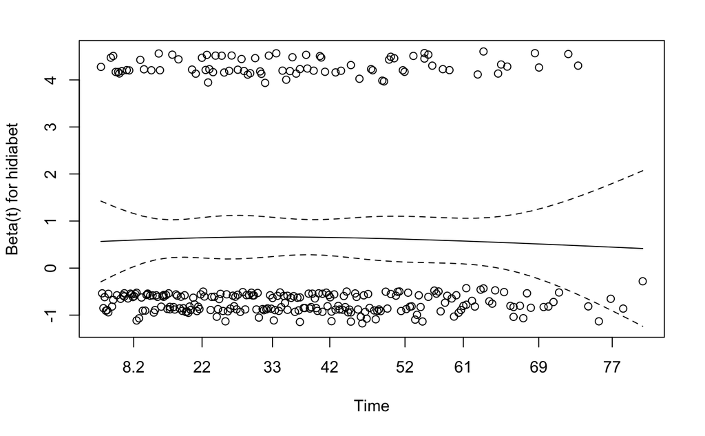

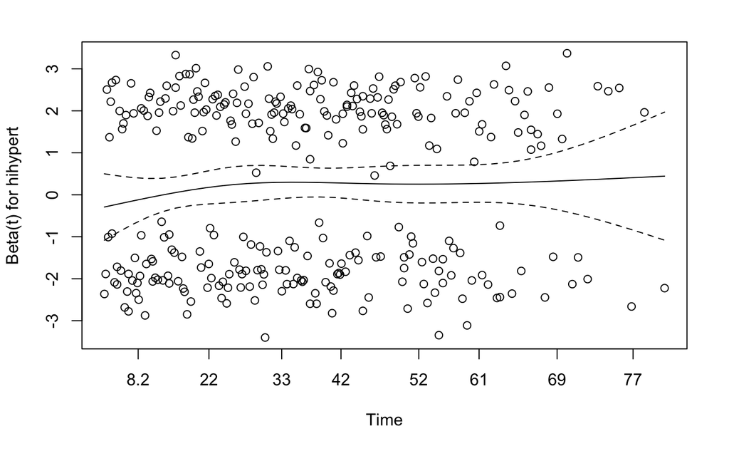

```r
plot(cox.zph(model1))
```

## 5(a)

Plot the estimated survival functions for following four patients: * patient A receiving the conventional therapy only (age=60, sysbp=140, gender=1, hidiabet=0, hihypert=1) * patient B receiving the ACE-inhibitor plus conventional therapy (age=140, sysbp=60, gender=1, hidiabet=0, hihypert=1) * patient C receiving the conventional therapy only (age=60, sysbp=140, gender=0, hidiabet=0, hihypert=1) * patient D receiving the ACE-inhibitor plus conventional therapy (age=140, sysbp=60, gender=0, hidiabet=0, hihypert=1)

```r
# Create the new data
a <- data.frame(row.names = NULL, check.rows = FALSE,
           check.names = TRUE, fix.empty.names = TRUE,
           stringsAsFactors = default.stringsAsFactors(),
                          'gender' = c(0,1),
                          'age' = c(60,60),
                          'hidiabet'=c(0,0),
                          'hihypert'=c(1,1),
                          'sysbp'=c(140,140)
                          )
a$gender<- as.factor(a$gender)
a$hidiabet<- as.factor(a$hidiabet)
a$hihypert<- as.factor(a$hihypert)

a
```

| gender | age | hidiabet | hihypert | sysbp |
| --- | --- | --- | --- | --- |
| 0 | 60 | 0 | 1 | 140 |
| 1 | 60 | 0 | 1 | 140 |

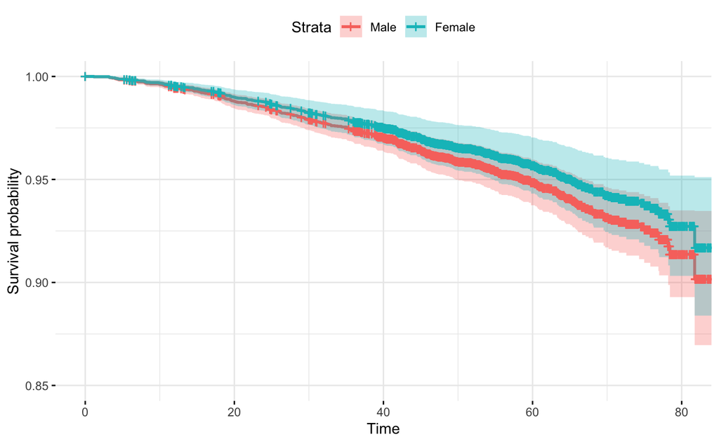

```r
fita <- survfit(model0, newdata = a)
ggsurvplot(fita, conf.int = TRUE,
           ggtheme = theme_minimal(), data = a,
           ylim = c(0.85, 1),
           legend.labs = c("Male","Female"),
)
```

```r
fitb <- survfit(model1, newdata = a, data = a)
fitb
```

```
Call: survfit(formula = model1, newdata = a, data = a)

     n events median 0.95LCL 0.95UCL
1 4153    299     NA      NA      NA
2 4153    299     NA      NA      NA
```

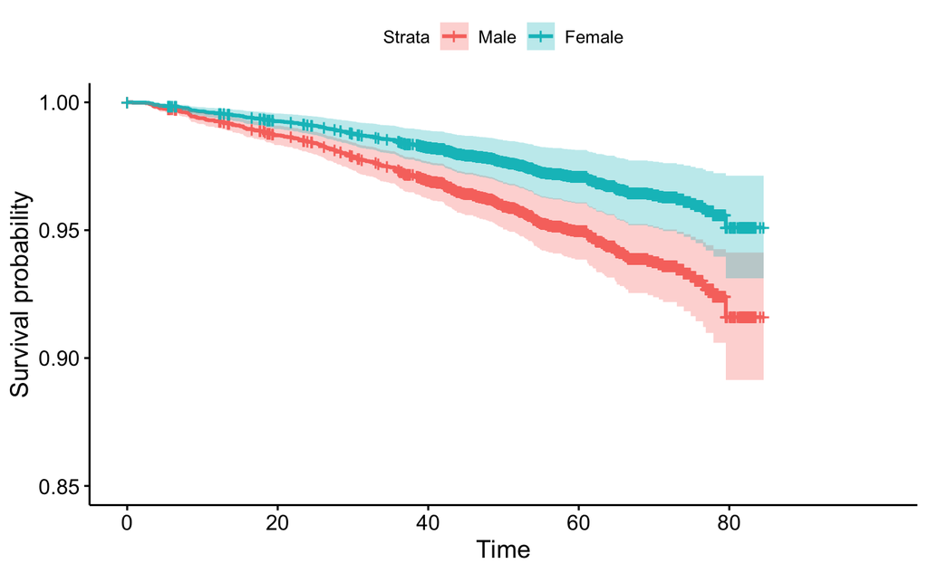

```r
ggsurvplot(fitb, conf.int = TRUE,
           ylim = c(0.85, 1), xlim =c(0,100),
           legend.labs = c("Male","Female")
)
```

## 5(b)

The researcher decides to use the restricted mean survival time (up to 80 months) to summarize the survival curve. What are the RMST for patients A and B based on your estimated survival curves.

```r
print(fita,print.rmean=TRUE)
```

```
Call: survfit(formula = model0, newdata = a)

     n events *rmean *se(rmean) median 0.95LCL 0.95UCL
1 4130    334   85.4      0.326     NA      NA      NA
2 4130    334   86.0      0.330     NA      NA      NA
    * restricted mean with upper limit =  89
```

```r
# Of 4130 observation, there are only 334 useful
print(fitb,print.rmean=TRUE)
```

```
Call: survfit(formula = model1, newdata = a, data = a)

     n events *rmean *se(rmean) median 0.95LCL 0.95UCL
1 4153    299   81.6      0.250     NA      NA      NA
2 4153    299   82.8      0.256     NA      NA      NA
    * restricted mean with upper limit =  84.6
```

```r
# Of 4153 observation, there are only 299 useful
```

```r
fita$surv
```

[output not shown]

[output cut: 487 more lines]